# Lista 2 Sobrevivencia

Davi Wentrick Feijó

2023-09-19

#### Exercıcio 1: Considere que o tempo de vida (em anos) de um equipamento eletronico pode ser representado por uma variavel aleatoria T com a seguinte funcao densidade de probabilidade:

$$f(t) = 2t e^{-t^2}$$

##### (a) Qual a probabilidade de um equipamento eletronico funcionar por mais de 1 ano ?

##### (b) Determine a funcao de risco h(t) e responda: O risco desse equipamento falhar aumenta ou diminui com o passar do tempo?

#### Exercıcio 2: Os dados da Tabela 1 referem-se aos tempo de sobrevivencia (em dias) de pacientes com cancer submetidos a radioterapia (o sımbolo + indica censura).

```
##    tempo censura
## 1      7       1
## 2     34       1
## 3     42       1
## 4     63       1
## 5     64       1
## 6     74       0
## 7     83       1
## 8     84       1
## 9     91       1
## 10   108       1
## 11   112       1
## 12   129       1
## 13   133       1
## 14   133       1
```

[output cut: 36 more lines]

##### (a) Determine as estimativas da S(t) e H(t) pelos metodos de Kaplan-Meier e Nelson-Aalen.

```
## Keplan-Meier
```

```
## Call: survfit(formula = Surv(dados$tempo, dados$censura) ~ 1)
##
##  time n.risk n.event survival std.err lower 95% CI upper 95% CI
##     7     50       1    0.980  0.0198       0.9420        1.000
##    34     49       1    0.960  0.0277       0.9072        1.000
##    42     48       1    0.940  0.0336       0.8764        1.000
##    63     47       1    0.920  0.0384       0.8478        0.998
##    64     46       1    0.900  0.0424       0.8206        0.987
##    83     44       1    0.880  0.0461       0.7936        0.975
##    84     43       1    0.859  0.0494       0.7676        0.962
##    91     42       1    0.839  0.0523       0.7422        0.948
##   108     41       1    0.818  0.0549       0.7174        0.933
##   112     40       1    0.798  0.0572       0.6932        0.918
##   129     39       1    0.777  0.0593       0.6694        0.903
##   133     38       2    0.736  0.0628       0.6230        0.870
```

[output cut: 26 more lines]

```
## Nelson-Aalen
```

```
## Call: survfit(formula = coxph(Surv(tempo, censura) ~ 1, method = "breslow"))
##
##  time n.risk n.event survival std.err lower 95% CI upper 95% CI
##     7     50       1   0.9802  0.0196      0.94252        1.000
##    34     49       1   0.9604  0.0274      0.90809        1.000
##    42     48       1   0.9406  0.0333      0.87761        1.000
##    63     47       1   0.9208  0.0380      0.84925        0.998
##    64     46       1   0.9010  0.0420      0.82227        0.987
##    83     44       1   0.8807  0.0457      0.79558        0.975
##    84     43       1   0.8605  0.0489      0.76975        0.962
##    91     42       1   0.8403  0.0518      0.74463        0.948
##   108     41       1   0.8200  0.0544      0.72009        0.934
##   112     40       1   0.7998  0.0567      0.69607        0.919
##   129     39       1   0.7795  0.0587      0.67249        0.904
##   133     38       2   0.7396  0.0622      0.62724        0.872
```

[output cut: 26 more lines]

##### (b) Construa os graficos da $\hat S(t)$ e $\hat H(t)$.

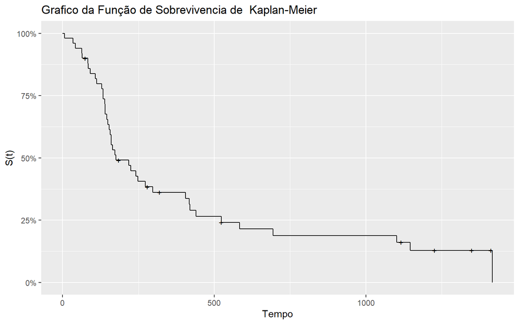

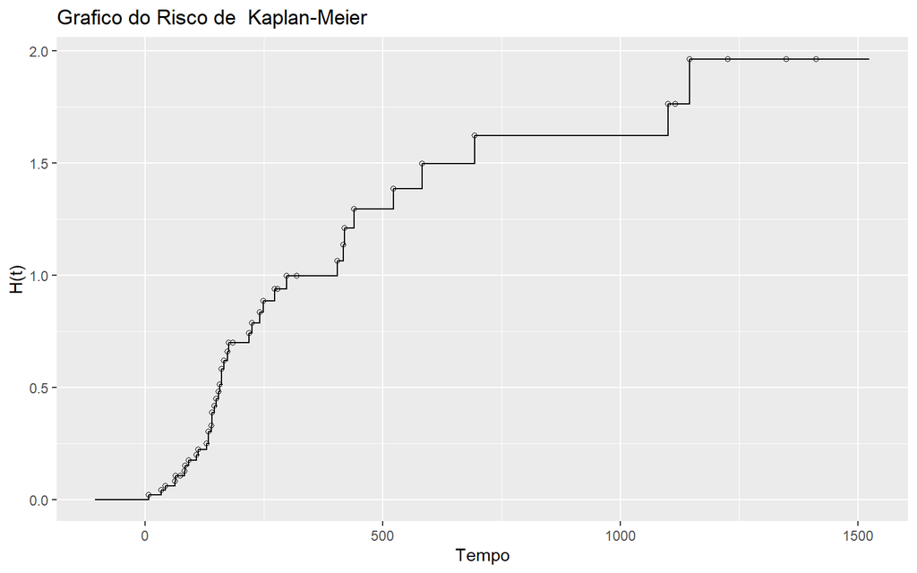

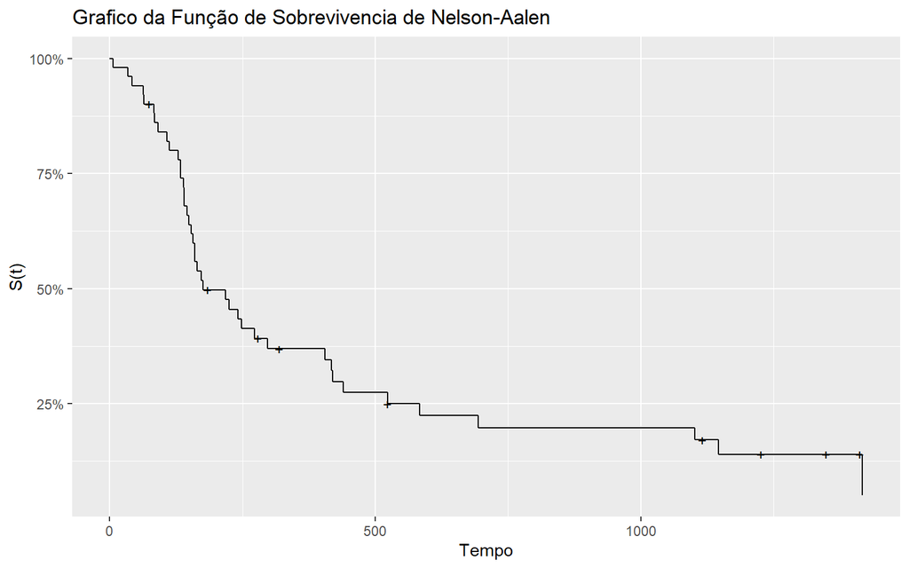

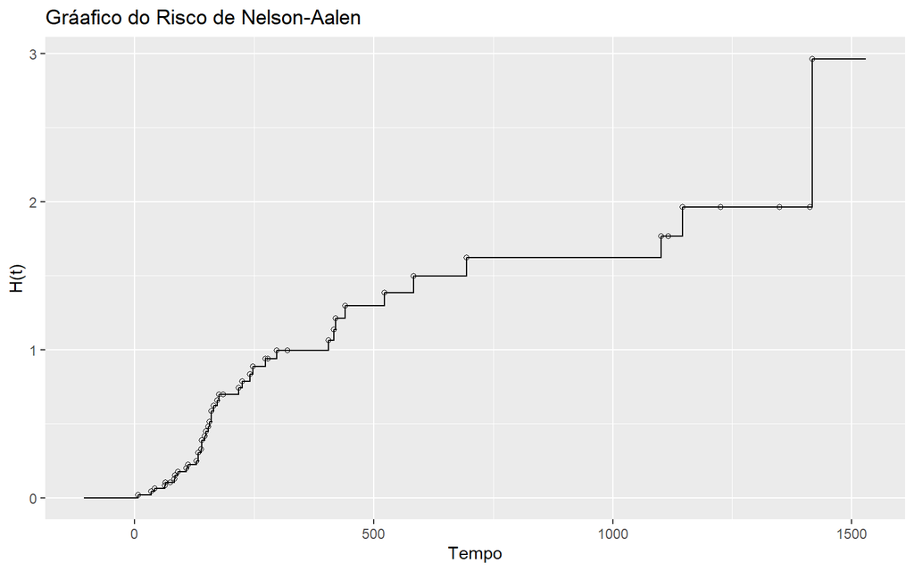

[figure not shown]

##### (c) Encontre a estimativa do tempo mediano.

```
## Call: survfit(formula = Surv(dados$tempo, dados$censura) ~ 1)
##
##       n events median 0.95LCL 0.95UCL
## [1,] 50     41    176     154     417
```

```
## Call: survfit(formula = coxph(Surv(tempo, censura) ~ 1, method = "breslow"))
##
##       n events median 0.95LCL 0.95UCL
## [1,] 50     41    176     154     417
```

##### (d) Qual a probabilidade de um paciente com cancer sobreviver a:

- 1. 42 dias ?

```
##   tempo surv_prob
## 3    42      0.94
```

- 2. 100 dias ?

Para os tempos a seguir é necessario fazer uma interpolacao ja que nao temos a observacao no banco

```
## [1] 0.8278824
```

- 3. 300 dias ?

```
## [1] 0.3613056
```

- 4. 1000 dias ?

```
## [1] 0.1674521
```

5. Interprete os resultados obtidos nos itens anteriores.

Podemos perceber que existe uma queda grande na probabilidade de sobrevivencia até os 200 dias, uma vez que passa desse ponto a queda deixa de ser repetentina e comeca a estabilizar, contudo vale notar que depois dos 200 dias nao temos muitas observacoes

6. Construa o grafico do tempo total em teste (curva TTT) e indique quais distribuicoes de probabilidade podem ser usadas para modelar os tempos de sobrevivencia de pacientes com cancer.

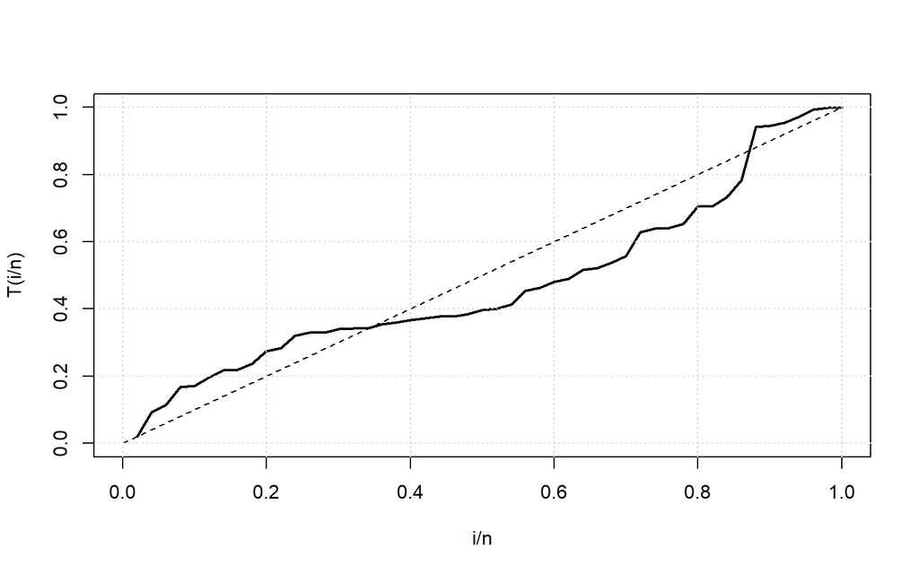

```r
TTT(tempo)
```

#### Exercıcio 3: Os dados apresentados na Tabela 2 representam o tempo (em dias) ate a morte de pacientes com cancer de ovario tratados na Mayo Clinic (Fleming, et al., 1980). O sımbolo + indica censura.

```r
tempo = c(28,89,175,195,309,377,393,421,447,462,709,744,770,1106,1206,34,88,137,
          199,280,291,299,300,309,309,351,358,369,370,375,382,392,429,451,1119)
censura = c(rep(1,5),rep(0,4),1,rep(0,5),rep(1,6),0,0,rep(1,9),0,1,0)
grupo = c(rep(1,15),rep(2,20))

dados = data.frame(tempo,censura,grupo) %>%
  arrange(tempo)%>%
  mutate(grupo = as.factor(grupo))
```

##### (a) Determine as estimativas da S(t) pelo metodo de Kaplan-Meier e construa o grafico da S(t). Interprete os resultados.

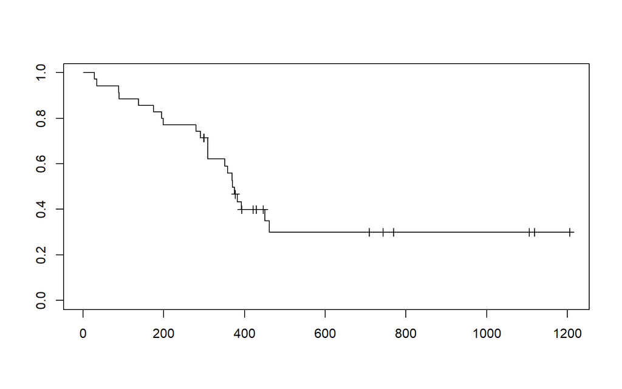

```r
KM = survfit(Surv(dados$tempo,dados$censura)~1)

plot(KM,conf.int = F, mark.time = T)
```

```r
summary(KM)
```

```
## Call: survfit(formula = Surv(dados$tempo, dados$censura) ~ 1)
##
##  time n.risk n.event survival std.err lower 95% CI upper 95% CI
##    28     35       1    0.971  0.0282        0.918        1.000
##    34     34       1    0.943  0.0392        0.869        1.000
##    88     33       1    0.914  0.0473        0.826        1.000
##    89     32       1    0.886  0.0538        0.786        0.998
##   137     31       1    0.857  0.0591        0.749        0.981
##   175     30       1    0.829  0.0637        0.713        0.963
##   195     29       1    0.800  0.0676        0.678        0.944
##   199     28       1    0.771  0.0710        0.644        0.924
##   280     27       1    0.743  0.0739        0.611        0.903
##   291     26       1    0.714  0.0764        0.579        0.881
##   309     23       3    0.621  0.0832        0.478        0.808
##   351     20       1    0.590  0.0847        0.445        0.782
##   358     19       1    0.559  0.0857        0.414        0.755
##   369     18       1    0.528  0.0864        0.383        0.728
##   370     17       1    0.497  0.0867        0.353        0.700
##   375     16       1    0.466  0.0867        0.323        0.671
##   382     14       1    0.433  0.0866        0.292        0.641
##   392     13       1    0.399  0.0861        0.262        0.609
##   451      8       1    0.349  0.0886        0.212        0.574
##   462      7       1    0.299  0.0889        0.167        0.536
```

##### (b) Repita a letra (a) considerando os grupos. Apresente o grafico da S(t) de cada grupo em um mesmo grafico. Interprete os resultados.

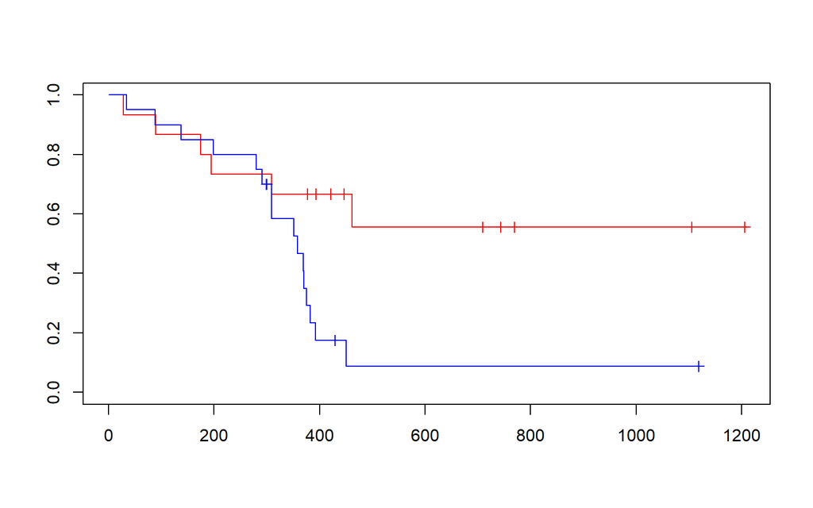

```r
KM = survfit(Surv(dados$tempo,dados$censura)~dados$grupo)

plot(KM,conf.int = F, mark.time = T, col = c("red","blue"))
```

##### (c) Teste a hipotese de igualdade das funcoes de sobrevivencia dos grupos usando dois testes diferentes. Os resultados dos testes sao consistentes ? Em caso negativo, explique a razao da diferenca dos resultados

```r
survdiff(Surv(tempo, censura) ~ grupo, data=dados, rho = 0)
```

```
## Call:
## survdiff(formula = Surv(tempo, censura) ~ grupo, data = dados,
##     rho = 0)
##
##          N Observed Expected (O-E)^2/E (O-E)^2/V
## grupo=1 15        6     11.4      2.53      5.65
## grupo=2 20       16     10.6      2.71      5.65
##
##  Chisq= 5.7  on 1 degrees of freedom, p= 0.02
```

```r
survdiff(Surv(tempo, censura) ~ grupo, data=dados, rho = 1)
```

```
## Call:
## survdiff(formula = Surv(tempo, censura) ~ grupo, data = dados,
##     rho = 1)
##
##          N Observed Expected (O-E)^2/E (O-E)^2/V
## grupo=1 15     4.66     7.43     1.032      2.81
## grupo=2 20    10.64     7.87     0.975      2.81
##
##  Chisq= 2.8  on 1 degrees of freedom, p= 0.09
```

##### (d) Construa o grafico do tempo total em teste (curva TTT), da H(t) e indique quais distribuicoes de probabilidade podem ser usadas para modelar os tempos de sobrevivencia de ratos.

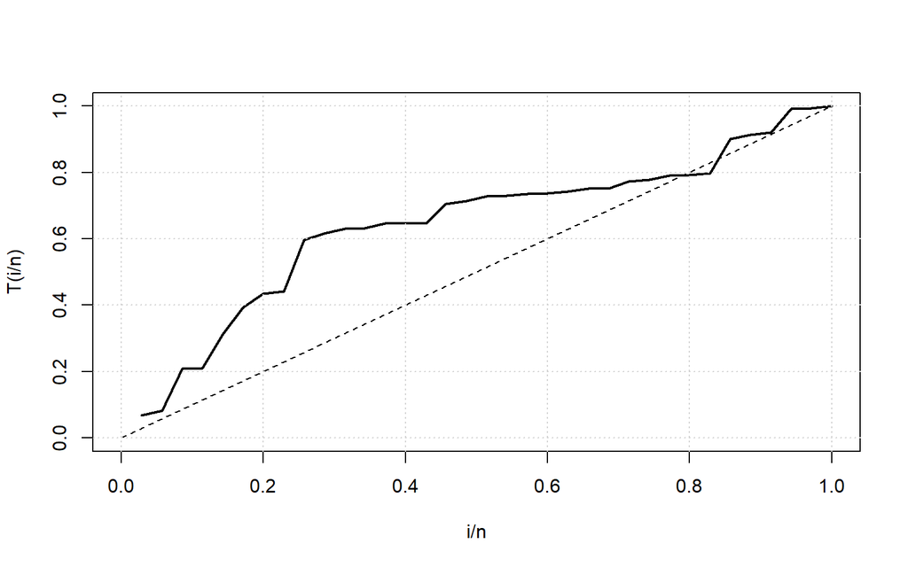

```r
TTT(tempo)
```

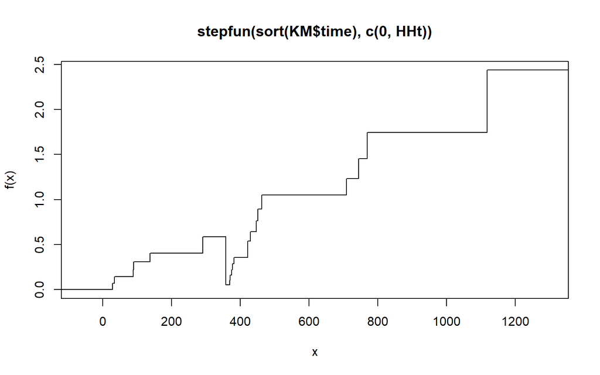

```r
#funcao de risco
HHt = -log(KM$surv)
plot(stepfun(sort(KM$time),c(0,HHt)),do.points = F)
```

#### Exercıcio 4: Um laboratorio interessado em investigar a relacao entre a dieta e o desenvolvimento de um tumor dividiu 90 ratos em tres grupos quanto ao tipo de dieta: baixo teor de gordura, saturada e nao saturada. Os ratos tinham a mesma idade, eram da mesma especie e tinham condicoes fısicas semelhantes. Os ratos foram observados por 200 dias e os tempos ate o surgimento de um tumor encontram-se na Tabela 3. O sımbolo + indica censura.